# Exploratory Data Analysis - N-gram Model

Jaime Hernandez

October 29, 2019

First load the data:

```r
setwd("~/Work/Training/Data Science Coursera/10-Capstone/Final_Project")

library(stringi)
```

```r
library(stringr)
library(ggplot2)
library(RColorBrewer)
library(dplyr)
library(tm)
library(wordcloud)
library(rJava)
library(RWeka)
library(textclean)
con <- file("./final/en_US/en_US.twitter.txt", open = "rb")
twitter <- readLines(con, encoding = "UTF-8", skipNul = TRUE)
close(con)

con <- file("./final/en_US/en_US.news.txt", open = "rb")
news <- readLines(con, encoding = "UTF-8", skipNul = TRUE)
close(con)

con <- file("./final/en_US/en_US.blogs.txt", open = "rb")
blog <- readLines(con, encoding = "UTF-8", skipNul = TRUE)
close(con)
```

Display general statistics about the three corpora.

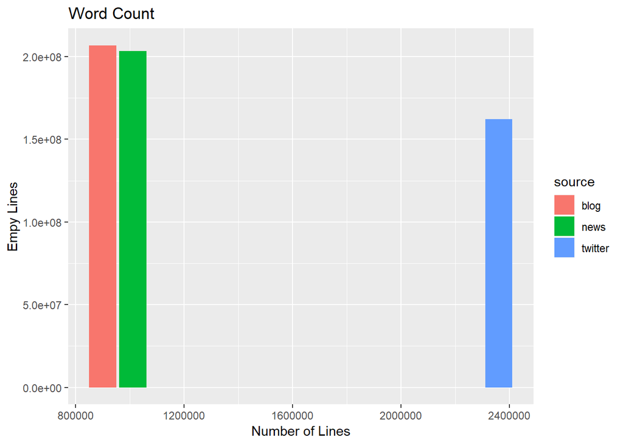

```r
stats_df <- data.frame(rbind(stri_stats_general(twitter),
                  stri_stats_general(news),
                  stri_stats_general(blog)),
                  source = c("twitter", "news", "blog")
                )

g.word.count <- ggplot(stats_df, aes(x = stats_df$Lines, y = stats_df$Chars, fill = source)) +
    geom_bar(stat = "identity") +
    ggtitle("Word Count") +
xlab("Number of Lines") +
ylab("Empy Lines")

g.word.count
```

```r
colnames(stats_df) <- c("Total Number of Lines", "Empty Lines", "Total Number of Characters", "Number of Empty Characters" , "Source")

stats_df
```

```
##   Total Number of Lines Empty Lines Total Number of Characters
## 1               2360148     2360148                  162096241
## 2               1010242     1010242                  203223154
## 3                899288      899288                  206824382
##   Number of Empty Characters  Source
## 1                  134082806 twitter
## 2                  169860866    news
## 3                  170389539    blog
```

Show frequencies of words found for each data source:

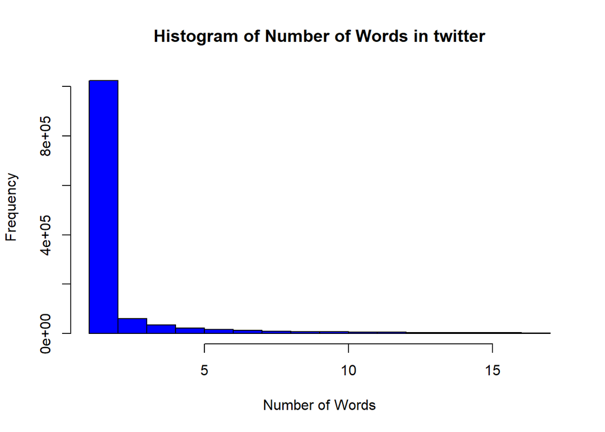

```r
#Twitter
twitter_chars <- strsplit(twitter," ") %>%
    unlist()

#Getting frequencies but only keeping the botton 95% of unique "words" to mitigate skewed data
twitter_freq <- table(twitter_chars) %>%
    as.data.frame()

twitter_count <- nrow(twitter_freq)

twitter_freq <- twitter_freq %>%
    top_n(round(twitter_count*.95), -Freq)


hist(twitter_freq$Freq, col = "blue", main = "Histogram of Number of Words in twitter", xlab = "Number of Words")
```

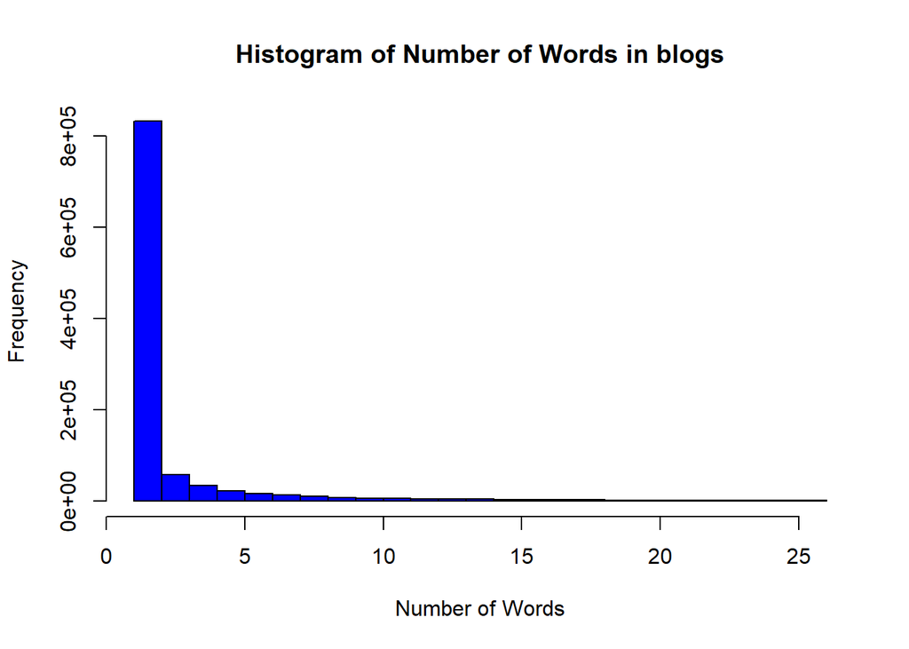

```r
#####
#Blogs

blog_chars <- strsplit(blog," ") %>%
    unlist()

#Getting frequencies but only keeping the botton 95% of unique "words" to mitigate skewed data
blog_freq <- table(blog_chars) %>%
    as.data.frame()

blog_count <- nrow(blog_freq)


blog_freq <- blog_freq %>%
    top_n(round(blog_count*.95), -Freq)


hist(blog_freq$Freq, col = "blue", main = "Histogram of Number of Words in blogs", xlab = "Number of Words")
```

[figure not shown]

```r
#####
#News

news_chars <- strsplit(news," ") %>%
    unlist()

#Getting frequencies but only keeping the botton 95% of unique "words" to mitigate skewed data
news_freq <- table(news_chars) %>%
    as.data.frame()

news_count <- nrow(news_freq)

news_freq <- news_freq %>%
    top_n(round(news_count*.95), -Freq)



hist(news_freq$Freq, col = "blue", main = "Histogram of Number of Words in blogs", xlab = "Number of Words")
```

Sampling data for modeling:

```r
blogsSample <- sample(blog, 6000)
newsSample <- sample(news, 6000)
twitterSample <- sample(twitter, 6000)

# save samples

sample <-c(blogsSample, newsSample, twitterSample)
```

Cleaning the data:

Looking into literature, a common approach was created to clean the data and edit the data files. Common punctiation (commas, periods, etc.) and other key character combinations such as smileys were marked to signify beginning/end of sentences. Common english stopwords such as “a, is, etc” were removed in order to get a more robust analysis of the corpora.

To remove profanity, a profanity text file was downloaded from google. All words in the sample corpora that include these profanity words were removed.

This function was written to signify the end of a sentence though it is not needed for this specific assignment.

```r
data_dir <- c("~/Work/Training/Data Science Coursera/10-Capstone/Final_Project")

cleanData <- function(data) {

        library(tm)

                    # Profanity filtering

                    f <- file(paste0(data_dir,"/profanity.txt"))
                    profanities<-readLines(f,encoding="UTF-8")
                    close(f)

                    data <- tolower(data) # convert to lowercase
                    data <- removeWords(data, profanities)
                    data <- removeWords(data, stopwords("english"))

                    data <- removeNumbers(data) # remove numbers
                    data <- replace_contraction(data)
                    pontuacao <-  '[.,!:;?]|:-\\)|:-\\(|:\\)|:\\(|:D|=D|8\\)|:\\*|=\\*|:x|:X|:o|:O|:~\\(|T\\.T|Y\\.Y|S2|<3|:B|=B|=3|:3'
                    data <- gsub(pontuacao," END ",data) # substitute selected ponctuation (including smileys) with the word END
                    data <- gsub("$"," END",data) # make sure every line ends with an END
                    data <- gsub("\\b(\\w+)\\s+\\1\\b","\\1",data) # remove duplicate words in sequence (eg.
                    data <- removePunctuation(data) # remove all other punctuation
                    data <- str_replace_all(data, "[[:punct:]]", "")
                    data <- stripWhitespace(data) # remove excess white space
                    data <- gsub("^[[:space:]]","",data) # make sure lines doesn't begin with space
                    data <- gsub("[[:space:]]$","",data) # make sure lines doesn't end with space


}
sample_clean <- cleanData(sample)
sample_clean <- removeWords(sample_clean, "END" )

c_sample_clean <- VCorpus(VectorSource(sample_clean))
```

N-gram Modeling

```r
#STarting with one worker
options(mc.cores = 1)
OnegramTokenizer <- function(x) NGramTokenizer(x, Weka_control(min = 1, max = 1))
memory.limit(size = 75000)
```

```
## [1] 75000
```

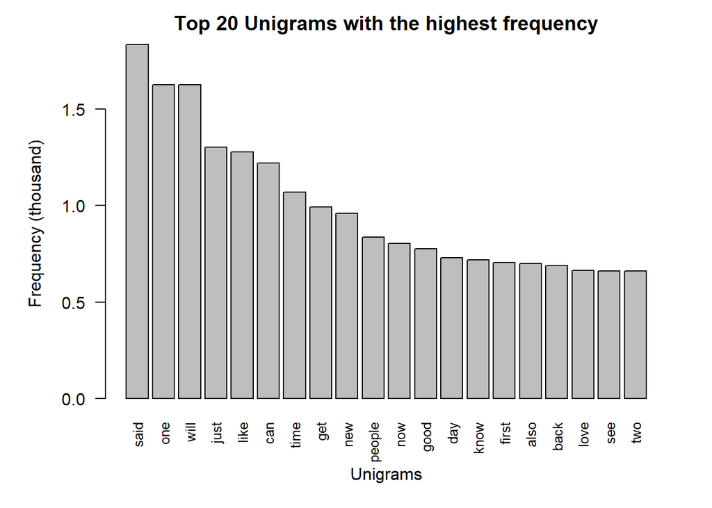

```r
oneGramMatrix<-as.matrix(TermDocumentMatrix(c_sample_clean, control=list(tokenize=OnegramTokenizer)))
onegramRowSum<-rowSums(oneGramMatrix)
onegram<-data.frame(onegram=names(onegramRowSum),freq=onegramRowSum)
onegramSorted<-onegram[order(-onegram$freq),]
par(mar = c(5, 5, 2, 2) + 0.2)
barplot(onegramSorted[1:20,]$freq/1000, horiz=F, cex.names=0.8, xlab="Unigrams",
    ylab="Frequency (thousand)",las=2,names.arg=onegramSorted[1:20,]$onegram,
    main="Top 20 Unigrams with the highest frequency")
```

No let’s analyze twograms

[figure not shown]

```r
TwogramTokenizer <- function(x) NGramTokenizer(x, Weka_control(min = 2, max = 2))

twogramMatrix <- TermDocumentMatrix(c_sample_clean, control=list(tokenize = TwogramTokenizer))

twoFreq <- findFreqTerms(twogramMatrix,lowfreq=10)
twogramRowSum <- rowSums(as.matrix(twogramMatrix[twoFreq,]))


barplot(twogramRowSum[1:20], horiz=F, cex.names=0.8, xlab="twograms",
         ylab="Frequency",las=2,names.arg=names(twogramRowSum[1:20]),
         main="Top 20 twogram with the highest frequency")
```

Now let’s analyze three-grams:

[figure not shown]

```r
TrigramTokenizer <- function(x) NGramTokenizer(x, Weka_control(min = 3, max = 3))

trigramMatrix <- TermDocumentMatrix(c_sample_clean, control=list(tokenize = TrigramTokenizer))

triFreq<-findFreqTerms(trigramMatrix,lowfreq=10)
trigramRowSum<-rowSums(as.matrix(trigramMatrix[triFreq,]))

barplot(trigramRowSum[1:20], horiz=F, cex.names=0.8,
         ylab="Frequency",las=2,names.arg=names(trigramRowSum[1:20]),
         main="Top 20 trigram with the highest frequency")
```

Now that the data is in a clean state and that intial analysis of the data has been completed, the next milestone will be to focuse on the predictive model.

Training data will be used to create initial models that will be tested using a test data extract as well.